# ME - GIA. Binary (Disaggregated vs. Aggregated)

09 oct. 2024

# Introduction

**This script has the goal to see the differences between aggregated and dissagregated data**

The *Elections_92.RData* file contains the results of a national sampling of potential voters. Specifically, it was a sample of 2198 nationwide voters in the United States on the act before the presidential elections in 1992.

**Outcome:**

- *pres*: whether the respondent voted for in the 1992 election (1 = yes, 0=no)
- *vota*: whether the respondent voted for in the 1992 election (Pres-Yes, Pres-No)

**Explanatory variables:**

- *age*: respondent’s age in years (numerical)
- *educ*: respondent’s years of education (numerical)
- *inter*: interest in the election (none, some, high)
- *close*: believes that the election will be close (yes, no)
- *sat*: satisfied with the candidates (yes, no)
- *party*: ideology (dem = democrat; ind = independent; rep = republican)
- *convictions*: convictions for the party (ind = indifferent; weak; strong)

```r
load("../Dades/Eleccions_92.RData")
```

# Description of the data

## Univariate exploratory data analysis

```r
summary(elecc92)
```

```
##       pres              vota           age             educ        inter
##  Min.   :0.0000   Pres-No : 669   Min.   :17.00   Min.   : 0.00   none:348
##  1st Qu.:0.0000   Pres-Yes:1529   1st Qu.:32.00   1st Qu.:12.00   some:962
##  Median :1.0000                   Median :42.00   Median :12.00   high:888
##  Mean   :0.6956                   Mean   :45.89   Mean   :12.96
##  3rd Qu.:1.0000                   3rd Qu.:59.00   3rd Qu.:15.00
##  Max.   :1.0000                   Max.   :91.00   Max.   :17.00
##        close           sat       convictions  party
##  Close-No : 400   Sat-No :1879   ind   :858   dem:1103
##  Close-Yes:1798   Sat-Yes: 319   weak  :685   ind: 266
##                                  strong:655   rep: 829
##
##
##
```

## Bivariate exploratory data analysis

A graphical bivariate descriptive of all explanatory variables versus the outcome could serve to see potential relationships.

It seems that all explanatory variables have some influence on the decision to vote. *Close* and *sat* less influence than the others.

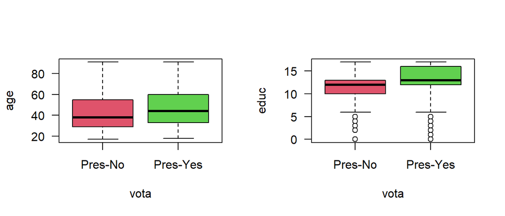

```r
par(mfrow=c(1,2),las=1)
boxplot(age ~vota, data=elecc92, col=2:3)
boxplot(educ~vota, data=elecc92, col=2:3)
```

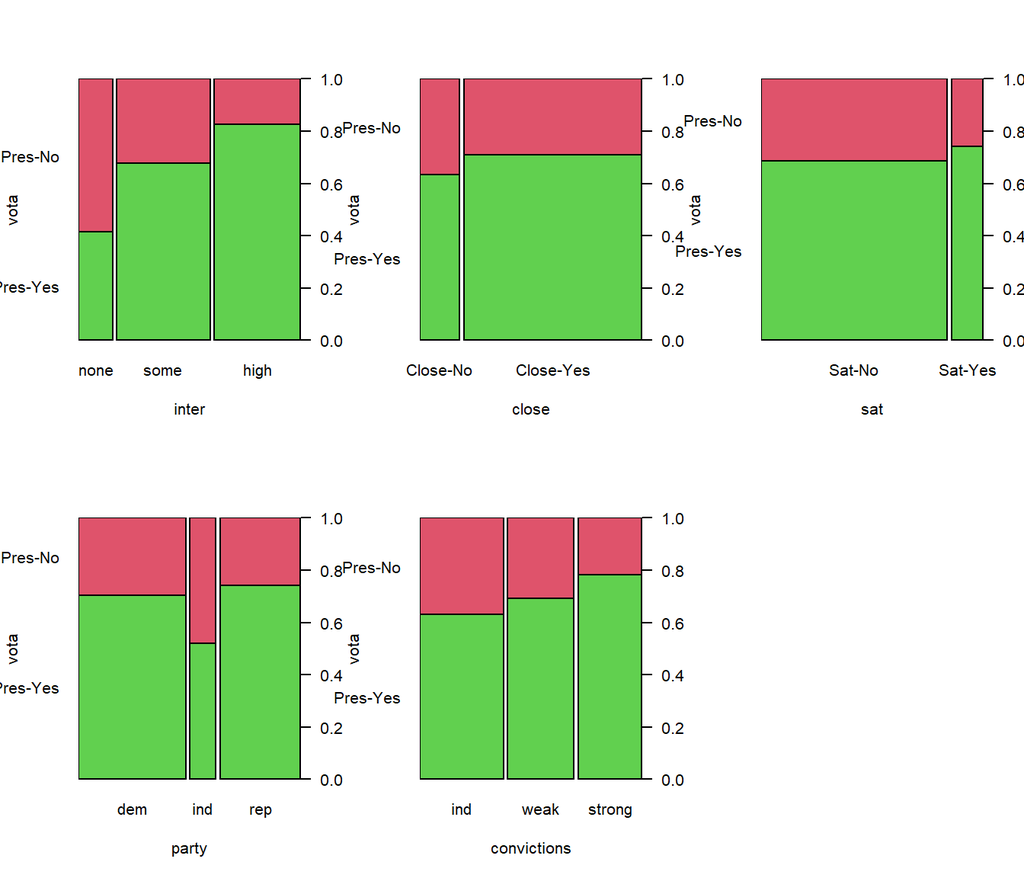

```r
par(mfrow=c(2,3),las=1)
plot(vota~inter,       data=elecc92, col=3:2)
plot(vota~close,       data=elecc92, col=3:2)
plot(vota~sat,         data=elecc92, col=3:2)
plot(vota~party,       data=elecc92, col=3:2)
plot(vota~convictions, data=elecc92, col=3:2)
```

# Models

## Disaggregated data

Fit the model only with continuous variable *age*. Age have a positive influence on the vote. The older, the greater propensity to vote

```r
m_age_dis <- glm(pres ~ age, data = elecc92, family = binomial(link= "logit"))
summary(m_age_dis)
```

```
##
## Call:
## glm(formula = pres ~ age, family = binomial(link = "logit"),
##     data = elecc92)
##
## Coefficients:
##             Estimate Std. Error z value Pr(>|z|)
## (Intercept) 0.218505   0.130528   1.674   0.0941 .
## age         0.013491   0.002756   4.895 9.81e-07 ***
## ---
## Signif. codes:  0 '***' 0.001 '**' 0.01 '*' 0.05 '.' 0.1 ' ' 1
##
## (Dispersion parameter for binomial family taken to be 1)
##
##     Null deviance: 2701.4  on 2197  degrees of freedom
## Residual deviance: 2676.7  on 2196  degrees of freedom
## AIC: 2680.7
##
## Number of Fisher Scoring iterations: 4
```

When disaggregated data is used then $m_i = 1$ and asymptotic theory does not apply. Deviance and Pearson statistics do not follow a $\chi^2$ distribution under the $H_0$ of well-fitted model.

As an informal rule of thumb at a fully disaggregated level for data, a model could be good if Deviance statistic is similar to the degrees of freedom of the model. Large values indicate lack of fit.

```r
c('Deviance'           = m_age_dis$deviance,
  'Degrees of freedom' = m_age_dis$df.res)
```

```
##           Deviance Degrees of freedom
##           2676.735           2196.000
```

**Does the model fit well the data?**

**Deviance >> Degrees of freedom $\rightarrow$ The model does not seem to fit well the data**.

## Aggregated data

An aggregated dataset is created using classes defined by age. We use the fucntion `aggregate`. **In this case, it is possible to aggregate by a continuous variable because it is discretized and the sample size is large enough**.

```r
dfage <- with(elecc92, aggregate(x   = cbind(ypos = pres, yneg = 1 - pres),
                                 by  = list("age" = age),
                                 FUN = sum))
head(dfage,4)
```

```
##   age ypos yneg
## 1  17    0    1
## 2  18    8    2
## 3  19    7    9
## 4  20   16   17
```

Fit the model with aggregated data and compare with the model with disaggregated data.

```r
m_age_agg <- glm(cbind(ypos,yneg) ~ age, data = dfage,
                 family = binomial(link= "logit"))
summary(m_age_agg)
```

```
##
## Call:
## glm(formula = cbind(ypos, yneg) ~ age, family = binomial(link = "logit"),
##     data = dfage)
##
## Coefficients:
##             Estimate Std. Error z value Pr(>|z|)
## (Intercept) 0.218505   0.130528   1.674   0.0941 .
## age         0.013491   0.002756   4.895 9.81e-07 ***
## ---
## Signif. codes:  0 '***' 0.001 '**' 0.01 '*' 0.05 '.' 0.1 ' ' 1
##
## (Dispersion parameter for binomial family taken to be 1)
##
##     Null deviance: 123.992  on 74  degrees of freedom
## Residual deviance:  99.299  on 73  degrees of freedom
## AIC: 349.2
##
## Number of Fisher Scoring iterations: 4
```

In the model, the coefficients are the same that those ones with disaggregated data, but not the deviance and degrees of freedom.

```r
data.frame(dis = round(c(coef(m_age_dis),                       # coefficients
                         deviance = m_age_dis$deviance,         # deviance
                         df       = m_age_dis$df.residual),3),  # degrees of freedom
           agg = round(c(coef(m_age_agg),
                         deviance = m_age_agg$deviance,
                         df       = m_age_agg$df.residual),3))
```

```
##                  dis    agg
## (Intercept)    0.219  0.219
## age            0.013  0.013
## deviance    2676.735 99.299
## df          2196.000 73.000
```

With aggregated data, we can use a formal test using the deviance statistic to check if the model fits well the data.

```r
deviance <- m_age_agg$deviance # deviance
df       <- m_age_agg$df.res   # degrees of freedom
1 - pchisq(deviance,df)        # p-value for hypothesis test
```

```
## [1] 0.02206015
```

**Does the model fit well the data?**

**p < 0.05 $\rightarrow$ The model does not seem to fit well the data**.

## Comparison with null model

The difference of deviances is the same in the two models. Thus, the statistic $\Delta D$ is appropriate to compare nested models using function `anova`.

```r
# Null model with disaggregated data
m_age_dis0 <- glm(pres ~ 1,
                  data   = elecc92,
                  family = binomial(link= "logit"))

# Null model with aggregated data
m_age_agg0 <- glm(cbind(ypos,yneg) ~ 1,
                  data   = dfage,
                  family = binomial(link= "logit"))

# Comparison with null model
anova(m_age_dis0, m_age_dis, test='Chisq')
```

```
## Analysis of Deviance Table
##
## Model 1: pres ~ 1
## Model 2: pres ~ age
##   Resid. Df Resid. Dev Df Deviance  Pr(>Chi)
## 1      2197     2701.4
## 2      2196     2676.7  1   24.693 6.721e-07 ***
## ---
## Signif. codes:  0 '***' 0.001 '**' 0.01 '*' 0.05 '.' 0.1 ' ' 1
```

```r
anova(m_age_agg0, m_age_agg, test='Chisq')
```

```
## Analysis of Deviance Table
##
## Model 1: cbind(ypos, yneg) ~ 1
## Model 2: cbind(ypos, yneg) ~ age
##   Resid. Df Resid. Dev Df Deviance  Pr(>Chi)
## 1        74    123.992
## 2        73     99.299  1   24.693 6.721e-07 ***
## ---
## Signif. codes:  0 '***' 0.001 '**' 0.01 '*' 0.05 '.' 0.1 ' ' 1
```

The statistic (**24.69**) and the p-value (**6.721e-07**) are the same.